# dplyr II: Joins and Set Ops

February 2, 2016

## Hadleyverse

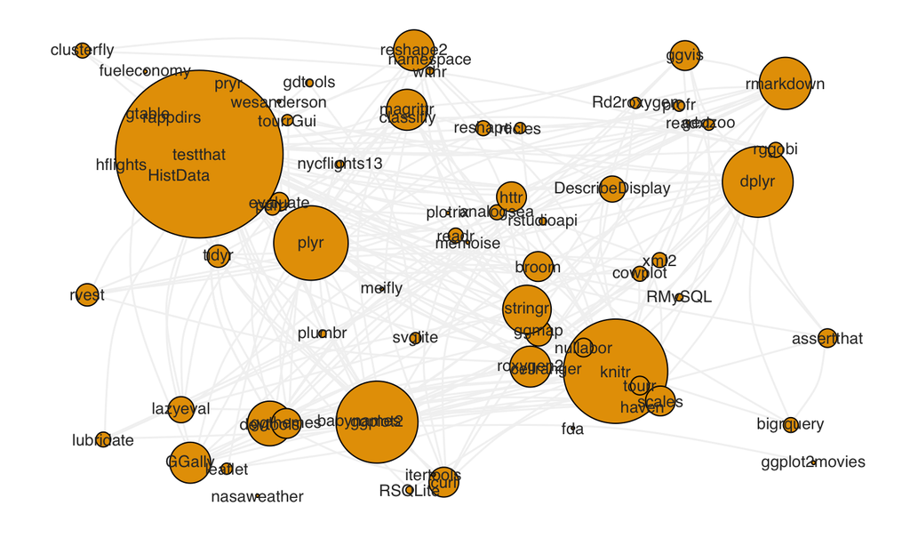

code shamelessly borrowed from : http://adolfoalvarez.cl/the-hitchhikers-guide-to-the-hadleyverse/

## Hadleyverse

- Ingest (rvest, readr, readxl)
- Manipulate (**dplyr**)
- Visualize (ggplot2, ggvis)
- Create packages (devtools, testthat)
- Simplify programming (purrr, lazyeval)
- and data packages (ggplot2movies, nycflights13)

## dplyr

dplyr provides a set of tools to assemble, transform, and summarize your data.

## Single table verbs

`dplyr` implements the following verbs useful for data manipulation:

- `select()`: focus on a subset of variables
- `filter()`: focus on a subset of rows
- `mutate()`: add new columns
- `summarise()`: reduce each group to a smaller number of summary statistics
- `arrange()`: re-order the rows

## More information about single table verbs

Michael Levy's Intro to dplyr presentation to D-RUG Oct. 2014 http://michaellevy.name/blog/dplyr-data-manipulation-in-r-made-easy/

## Multiple table verbs (Joins)

In addition to single table verbs, there are also a set of verbs that operate on two tables at a time: joins and set operations.

- Joins
  - `inner_join(x, y)`: matching x + y
  - `left_join(x, y)`: all x + matching y
  - `semi_join(x, y)`: all x with match in y
  - `anti_join(x, y)`: all x without match in y
- Sets
  - `intersect(x, y)`: all rows in both x and y
  - `union(x, y)`: rows in either x or y
  - `setdiff(x, y)`: rows in x, but not y

## Why Joins?

Real data is messy.

[figure not shown]

## Example Data Joins

```r
require(dplyr)
set.seed(12345) #that's amazing, I've got the same combination on my luggage!
x <- data.frame(key= LETTERS[c(1:3, 5)], value1 = sample(1:10, 4), stringsAsFactors = FALSE)
y <- data.frame(key= LETTERS[c(1:4)], value2 = sample(1:10, 4), stringsAsFactors = FALSE)

x
```

```
##   key value1
## 1   A      8
## 2   B     10
## 3   C      7
## 4   E      9
```

```r
y
```

```
##   key value2
## 1   A      5
## 2   B      2
## 3   C      3
## 4   D      4
```

## inner_join

Rows with matching keys from x and y.

[figure not shown]

```r
inner_join(x, y, by = "key")
```

```
##   key value1 value2
## 1   A      8      5
## 2   B     10      2
## 3   C      7      3
```

## left_join

All rows from x and those that match the key in y.

[figure not shown]

```r
left_join(x, y, by = "key")
```

```
##   key value1 value2
## 1   A      8      5
## 2   B     10      2
## 3   C      7      3
## 4   E      9     NA
```

## right_join

All rows from y and those that match the key in x.

[figure not shown]

```r
right_join(x, y, by = "key")
```

```
##   key value1 value2
## 1   A      8      5
## 2   B     10      2
## 3   C      7      3
## 4   D     NA      4
```

## full_join

All rows from x and y.

[figure not shown]

```r
full_join(x, y, by = "key")
```

```
##   key value1 value2
## 1   A      8      5
## 2   B     10      2
## 3   C      7      3
## 4   E      9     NA
## 5   D     NA      4
```

## Duplicate keys

When you match keys on non-unique rows you get all possible combinations out. Be careful.

[figure not shown]

## Filtering Joins

Semi and Anti joins don't actually join two datasets together. They filter one dataset based upon what's in another. This is useful when:

- you want to filter your dataset based upon another (semi)
- or want to understand what isn't in both datasets (anti)

## semi_join

All rows from x that have a key match in y.

[figure not shown]

```r
semi_join(x, y, by = "key")
```

```
##   key value1
## 1   A      8
## 2   B     10
## 3   C      7
```

## anti_join

All rows from x that have no key match in y.

[figure not shown]

```r
anti_join(x, y, by = "key")
```

```
##   key value1
## 1   E      9
```

## Want everything that doesn't match?

Combine join statements.

```r
full_join(anti_join(x,y, by = "key"), anti_join(y,x, by = "key"), by= "key")
```

```
##   key value1 value2
## 1   E      9     NA
## 2   D     NA      4
```

## Different keys?

Real data is messy. If key1 is "date" and key2 is "Date" things break. So, specify:

```r
set.seed(12345) #that's amazing, I've got the same combination on my luggage!
x <- data.frame(keyX= LETTERS[c(1:3, 5)], value1 = sample(1:10, 4), stringsAsFactors = FALSE)
y <- data.frame(keyY= LETTERS[c(1:4)], value2 = sample(1:10, 4), stringsAsFactors = FALSE)

full_join(x, y)
```

```
## Error: No common variables. Please specify `by` param.
```

```r
full_join(x, y, by=c("keyX" = "keyY"))
```

```
##   keyX value1 value2
## 1    A      8      5
## 2    B     10      2
## 3    C      7      3
## 4    E      9     NA
## 5    D     NA      4
```

## Set operations

You have two datasets that should be the same, but you're not sure if they are. How do you easily test that they are the same?

- Sets
  - `intersect(x, y)`: all rows in both x and y
  - `union(x, y)`: rows in either x or y
  - `setdiff(x, y)`: rows in x, but not y

## Set Operations

Set operations are on the entire row, there is no "key".

[figure not shown]

## Example Data Set Ops

```r
df1 <- data_frame(x = LETTERS[1:2], y = c(1L, 1L))
df2 <- data_frame(x = LETTERS[1:2], y = 1:2)

df1
```

```
## Source: local data frame [2 x 2]
##
##       x     y
##   (chr) (int)
## 1     A     1
## 2     B     1
```

```r
df2
```

```
## Source: local data frame [2 x 2]
##
##       x     y
##   (chr) (int)
## 1     A     1
## 2     B     2
```

## intersect

Which rows are common in both datasets?

```r
dplyr::intersect(df1, df2)
```

```
## Source: local data frame [1 x 2]
##
##       x     y
##   (chr) (int)
## 1     A     1
```

## union

Want all unique rows between both datasets?

```r
dplyr::union(df1, df2)
```

```
## Source: local data frame [3 x 2]
##
##       x     y
##   (chr) (int)
## 1     B     2
## 2     B     1
## 3     A     1
```

## setdiff

What's unique to df1?

```r
dplyr::setdiff(df1, df2)
```

```
## Source: local data frame [1 x 2]
##
##       x     y
##   (chr) (int)
## 1     B     1
```

What's unique to df2?

```r
dplyr::setdiff(df2, df1)
```

```
## Source: local data frame [1 x 2]
##
##       x     y
##   (chr) (int)
## 1     B     2
```

## Questions

?

More information: - http://r4ds.had.co.nz/relational-data.html

All diagrams courtesy of Hadley Wickham